# msa.destTest

이상인

2017년 5월 8일

#### **msa.destTest(Type 2 study)**

- 함수 명: msa.destTest(operators, parts, results, method = “nested”, lsl, usl, alpha = 0.05, sigma = 6, digits = 5, randomize = FALSE, main = “Gage R&R destructive Testing”, sub = “My MSA project”)
- Variables:
  - operators : 측정 작업자
  - parts : 부품 데이터
  - results : 측정 데이터
  - method : 파괴검사를 하기 위한 option (default = “nested”)
  - lsl: 하한 (default = NA)
  - usl: 상한 (default = NA)
  - alpha: 유의수준 alpha (default = 0.05)
  - sigma: 연구변동,표준편차 (default = 6)
  - digits: 결과값 최소단위 (default = 5)
  - randomize : gageRRDesign() 진행시 순서를 randomize 함. (default = FALSE)
  - main: 대제목 (default = “Gage R&R destructive Testing”)
  - sub: 소제목 (default = “My MSA project”)
- 기타 사용 package:
  - qualityTools:
    1. gageRRDesign() – gageRR을 진행하기 위해 측정자, 부품, 반복 수에 대한 표를 구축함
    2. response() – gageRRDesign으로 만들어진 표의 Measurement 변수에 데이터를 넣음
    3. gageRR() – method = “nested” 설정을 하면 파괴검사를 진행 함.

##### **함수 작동원리**

1. 받은 데이터에 측정자 수, 부품 수 , 반복 수를 구함.

```
  op_level <- nlevels(data[[operators]])
  pa_level <- nlevels(data[[parts]]) / op_level
  me_level <- length(data[[results]]) / nlevels(data[[parts]])
```

2. gageRRDesign()을 진행, response()를 이용하여 Measurement 변수에 데이터를 넣음

```
  gdo <- gageRRDesign(Operators = op_level, Parts = pa_level, Measurements = me_level,
                     method = method,sigma = sigma, randomize = randomize)
  response(gdo) <- data[[results]]
```

```
##    StandardOrder RunOrder Operator Part Measurement
## 1              1        1        A    A     15.4257
## 2              2        2        A    A     16.8677
## 3              3        3        A    B     15.5018
## 4              4        4        A    B     15.1628
## 5              5        5        A    C     15.7251
## 6              6        6        A    C     12.8191
## 7              7        7        A    D     15.1429
## 8              8        8        A    D     13.8563
## 9              9        9        A    E     14.1119
## 10            10       10        A    E     16.5675
## 11            11       11        B    A     13.1025
## 12            12       12        B    A     15.5494
## 13            13       13        B    B     13.8316
## 14            14       14        B    B     14.2388
```

[output cut: 16 more lines]

3. gageRR()을 이용하여 파괴검사 진행

```
  if(!missing(lsl) && !missing(usl)){
    gdo <- gageRR(gdo, method=method, sigma=sigma, alpha=alpha,tolerance = c(lsl,usl),dig = digits)


  }else{
    gdo <- gageRR(gdo,method=method,sigma=sigma,alpha=alpha,dig = digits)

  }
```

```
##
## AnOVa Table -  nested Design
##               Df Sum Sq Mean Sq F value Pr(>F)
## Operator       2  0.014  0.0071   0.005  0.995
## Operator:Part 12 22.055  1.8379   1.425  0.255
## Residuals     15 19.340  1.2893
##
## ----------
##
## Gage R&R
##                  VarComp VarCompContrib   Stdev StudyVar StudyVarContrib
## totalRR           1.2893        0.82457 1.13549   6.8129         0.90806
##  repeatability    1.2893        0.82457 1.13549   6.8129         0.90806
##  reproducibility  0.0000        0.00000 0.00000   0.0000         0.00000
## Part to Part      0.2743        0.17543 0.52374   3.1424         0.41884
## totalVar          1.5636        1.00000 1.25045   7.5027         1.00000
##                  P/T Ratio
## totalRR            0.71715
##  repeatability     0.64885
##  reproducibility   0.00000
## Part to Part       0.29928
## totalVar           0.78976
##
## ---
##  * Contrib equals Contribution in %
##  **Number of Distinct Categories (truncated signal-to-noise-ratio) = 1
```

4. 시각화

```
    plot(gdo)
```

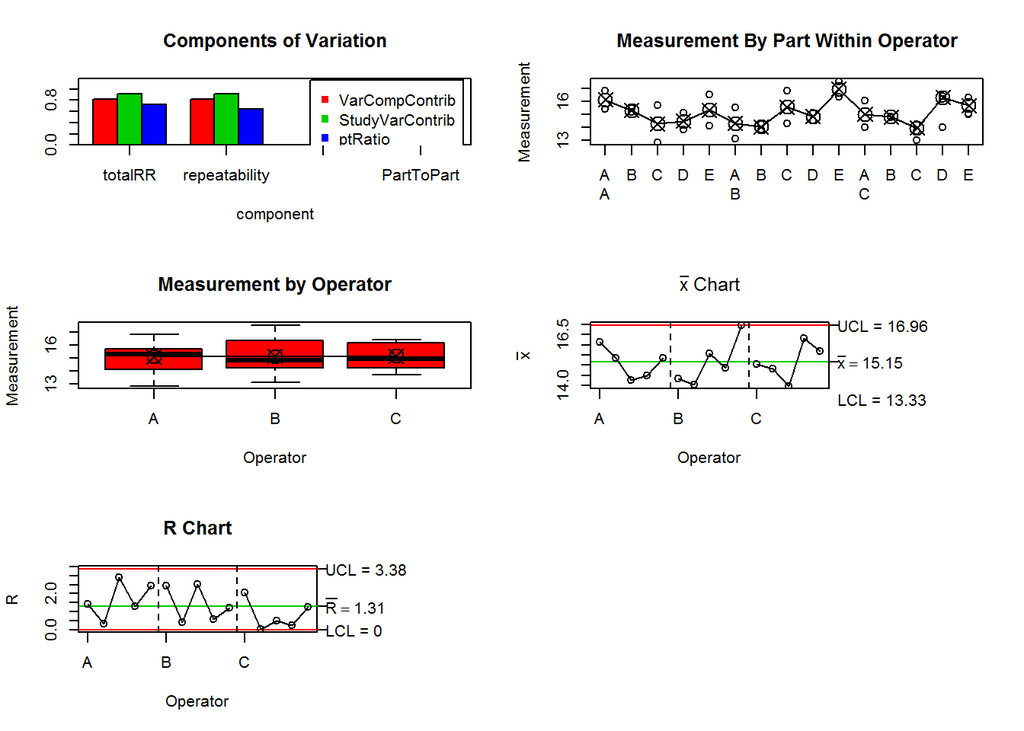